# Sensitivity analysis of the difference between two databases

Muchen Wang

2024-05-06

# Initialization

```r
rm(list=ls());gc()
```

```
##          used (Mb) gc trigger (Mb) max used (Mb)
## Ncells 511198 27.4    1138442 60.8   644245 34.5
## Vcells 901870  6.9    8388608 64.0  1634948 12.5
```

```r
graphics.off()
# loads package
library(sensemakr)
library(ggplot2)
library(dplyr)
library(tidyr)
v1.2 = read.csv("../data/GlobalAlienSpeciesFirstRecordDatabase_v1.2.csv")
v2 = read.csv("../data/GlobalAlienSpeciesFirstRecordDatabase_v2.csv")
v3.1 = read.csv("../data/GlobalAlienSpeciesFirstRecordDatabase_v3.1_freedata.csv")
```

# Function

```r
tr_df = function(v){
  df = v %>%
    filter(FirstRecord >= t0)

  species_count_df <- df %>%
    group_by(FirstRecord) %>%
    summarise(Count = n(), .groups = 'drop')

  b <- max(species_count_df$FirstRecord)
  all_years_df <- data.frame(FirstRecord = t0:b)

  species_count_df <- merge(all_years_df, species_count_df, by = "FirstRecord", all.x = TRUE)

  species_count_df$Count[is.na(species_count_df$Count)] <- 0
  return(species_count_df)
}

invasion_growth <- function(t, K, r, t_m, r_d, t_d) {
  if (t<t_d) {
    K / (1 + exp(-r * (t - t_m)))
  }else{
    result = K / (1 + exp(-r * (t - t_m))) - exp(r_d * (t-t_d))
    if (result < 0){
      0
    }else{
      result
    }
  }
}

# Define the sigmoid functions for Pd and Pr
sigmoid_function <- function(t, yoi, beta, rate, p0) {
  1-exp(-rate * (t - yoi)^beta - p0)
}

calculate_Fb <- function(a, I, pd_beta, r_pd, pr_beta, r_pr, pd0, pr0, t0, b) {
  Fb <- 0
  for (i in t0:a) {
    pd_product <- if (i < a) {
      prod(1 - sapply(i:(a-1), sigmoid_function, i, pd_beta, r_pd, pd0))
    } else {
      1
    }
    pd_current <- sigmoid_function(a, i, pd_beta, r_pd, pd0)
    pr_product <- 1-prod(1 - sapply(a:b, sigmoid_function, a, pr_beta, r_pr, pr0))

    Fb <- Fb + I[i - t0 + 1] * pd_product * pd_current * pr_product
  }
  return(Fb)
}

predict_F <- function(K, r, t_m, r_d, t_d, pd_beta, r_pd, pr_beta, r_pr, pd0, pr0, t0, b){
  cat("Start predicting--------------\n")
  years <- t0:b
  I <- sapply(years, invasion_growth, K, r, t_m, r_d, t_d)
  # Calculate Fb_values
  Fb_values <- sapply(years, function(a) {
    Fb <- calculate_Fb(a, I, pd_beta, r_pd, pr_beta, r_pr, pd0, pr0, t0, b)
    # cat("Year:", a, "Fb:", Fb, "\n")
    return(Fb)
  })
  cat("Finish predicting-------------\n")
  result <- data.frame(year = years, pre = Fb_values, invasion = I)
  return(result)
}

generate_random_params <- function(param_ranges) {
  params <- sapply(param_ranges, function(range) {
    runif(1, min = range[1], max = range[2])
  })

  return(params)
}

s_analysis = function(param_ranges, diff_obs, t0){
  # Generate random parameters
  params <- generate_random_params(param_ranges)
  # Use these parameters to predict F values for b1 and b2
  results_b1 <- predict_F(K = params['K'], r = params['r'], t_m = params['t_m'],
                          r_d = params['r_d'], t_d = params['t_d'],
                          pd_beta = params['pd_beta'], r_pd = params['r_pd'],
                          pr_beta = params['pr_beta'], r_pr = params['r_pr'],
                          pd0 = params['pd0'], pr0 = params['pr0'],
                          t0 = t0, b = 2016)

  results_b2 <- predict_F(K = params['K'], r = params['r'], t_m = params['t_m'],
                          r_d = params['r_d'], t_d = params['t_d'],
                          pd_beta = params['pd_beta'], r_pd = params['r_pd'],
                          pr_beta = params['pr_beta'], r_pr = params['r_pr'],
                          pd0 = params['pd0'], pr0 = params['pr0'],
                          t0 = t0, b = 2021)

  # Compute the difference in F values and the correlation with actual invasion
  common_years <- intersect(results_b1$year, results_b2$year)
  diff_F <- results_b2$pre[common_years - t0 + 1] - results_b1$pre[common_years - t0 + 1]

  cr = cor(diff_F[396:417], common_years[396:417])
  list(parameters = params, correlation = cr, result_b1 = results_b1, results_b2 = results_b2, diff_F = diff_F)
}
```

# Simulations

```r
t0 = 1600
b1 = 2016
b2 = 2021

years <- t0:b2

#Sensitivity analysis
#change the parameters of invasions, keeping the pd and pr
# Define the range for each parameter
param_ranges <- list(
  K = c(100, 1000),
  r = c(0.01, 0.5),     # Replace with actual ranges
  t_m = c(1800, 2024),       # Replace with actual ranges
  r_d = c(0, 1), # Replace with actual ranges
  t_d = c(1970, 2024),
  pd_beta = c(0, 1),
  r_pd = c(0.01, 0.2),
  pd0 = c(0.001, 0.01),
  pr_beta = c(0, 1),
  r_pr = c(0.001, 0.2),
  pr0 = c(0.001, 0.01)
)


df_v1 = tr_df(v1.2)
df_v2 = tr_df(v2)
df_v3 = tr_df(v3.1)
diff_obs = df_v2$Count[1:length(df_v1$Count)]-df_v1$Count
diff_obs2 = df_v3$Count[1:length(df_v2$Count)]-df_v2$Count
df_v1$diffv1v2 = diff_obs
df_v2$diffv2v3 = diff_obs2
# correlations <- replicate(10, s_analysis(param_ranges, diff_obs, t0))

# saveRDS(correlations, "../model_result/sensitivity_analysis.rds")

increase_correlations = readRDS("../model_result/sensitivity_analysis_corrected_300_I_increase.rds")
decrease_correlations = readRDS("../model_result/sensitivity_analysis_corrected_300_I_decline.rds")
```

# Analysis

This section of the document analyzes trends in species invasion data across different versions of the first record database. We focus on identifying changes over time and hypothesize reasons behind these trends.

## Initial Observations from Graphical Analysis

From our initial graphical analysis, we observe a notable trend where differences in the recorded invasions between database versions become flat starting from specific years.

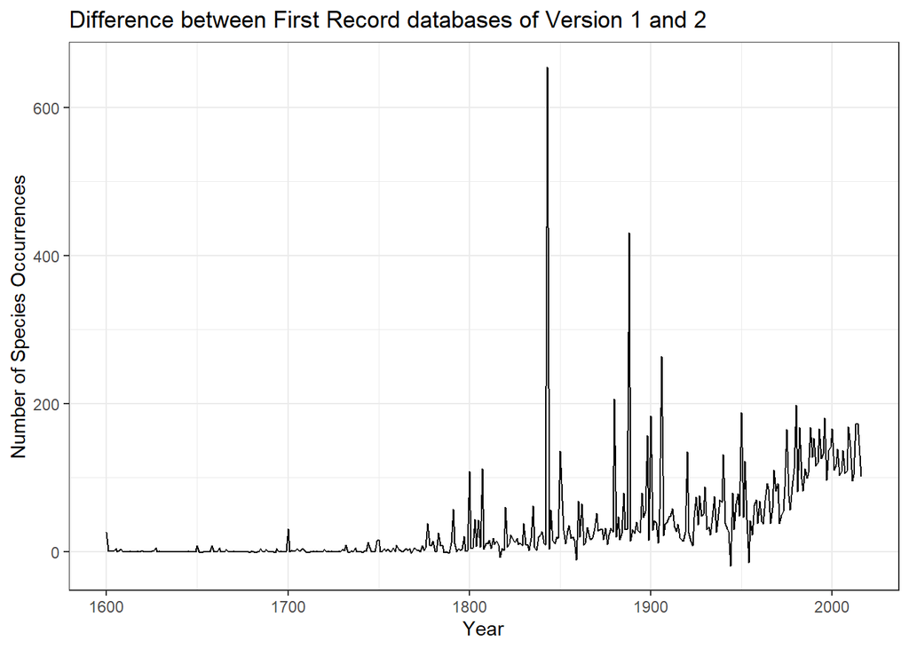

```r
ggplot(df_v1, aes(x = FirstRecord, y = diffv1v2)) +
    geom_line() +
    labs(title = "Difference between First Record databases of Version 1 and 2",
         x = "Year",
         y = "Number of Species Occurrences") +
    theme_bw()
```

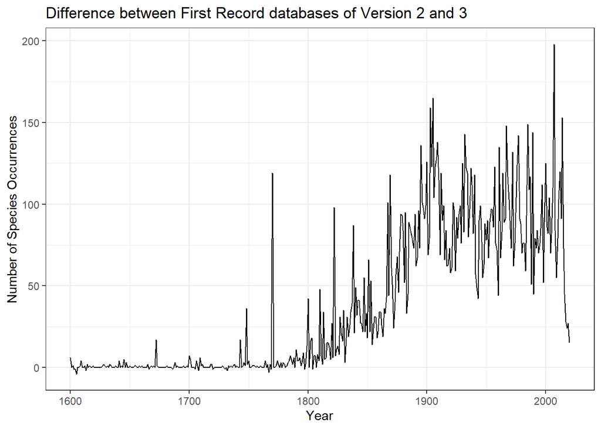

```r
ggplot(df_v2, aes(x = FirstRecord, y = diffv2v3)) +
    geom_line() +
    labs(title = "Difference between First Record databases of Version 2 and 3",
         x = "Year",
         y = "Number of Species Occurrences") +
    theme_bw()
```

We hypothesized that the observed flattening trend could be due to a decline in actual invasions. Under the assumption that if invasions were increasing indefinitely, we would expect to see a corresponding increase in the differences reported between database versions. This hypothesis is tested by examining correlations and analyzing the slopes of these differences over time. Here are two examples of the actual invasion used for sensitivity analysis. However, the ranges of parameters need to be improved to make it more resemble of the real situation.

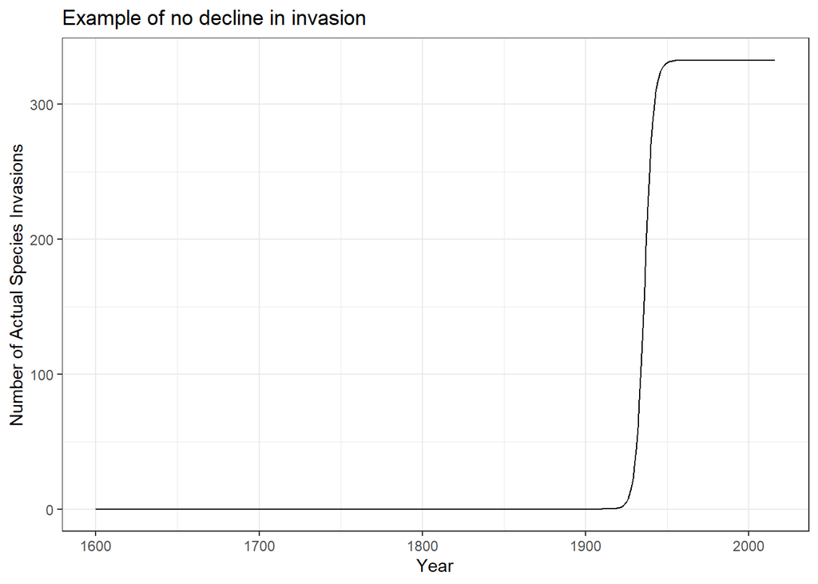

```r
#examples for both cases
#no decline
ggplot(increase_correlations[3,1]$results_b1, aes(x = year, y = invasion)) +
    geom_line() +
    labs(title = "Example of no decline in invasion",
         x = "Year",
         y = "Number of Actual Species Invasions") +
    theme_bw()
```

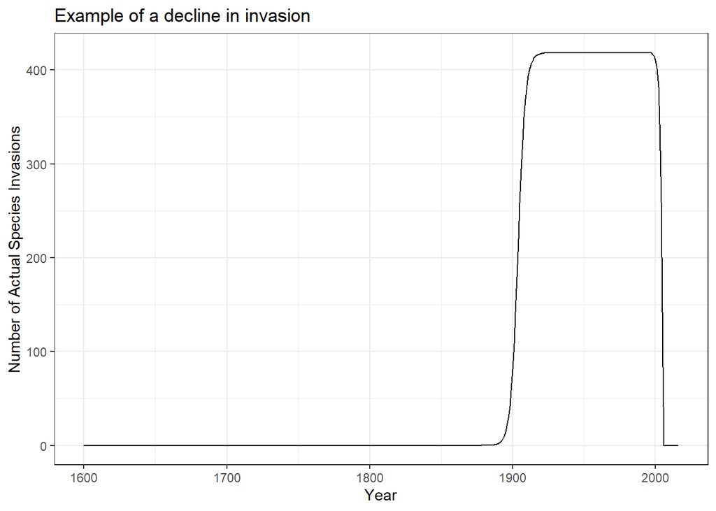

```r
ggplot(decrease_correlations[3,1]$results_b1, aes(x = year, y = invasion)) +
    geom_line() +
    labs(title = "Example of a decline in invasion",
         x = "Year",
         y = "Number of Actual Species Invasions") +
    theme_bw()
```

The distributions of the correlation coefficients between ΔF (the difference in records) and chronological time exhibit a left-skewed profile for both scenarios: where the actual invasion rates increase indefinitely and where they do not. Notably, instances of negative and low correlation coefficients are significantly more frequent in the scenario where invasion rates do not increase indefinitely. This pattern suggests that a perpetual increase in actual invasions is unlikely to account for the observed phenomena, implying that other factors might influence the flat trends detected in the data.

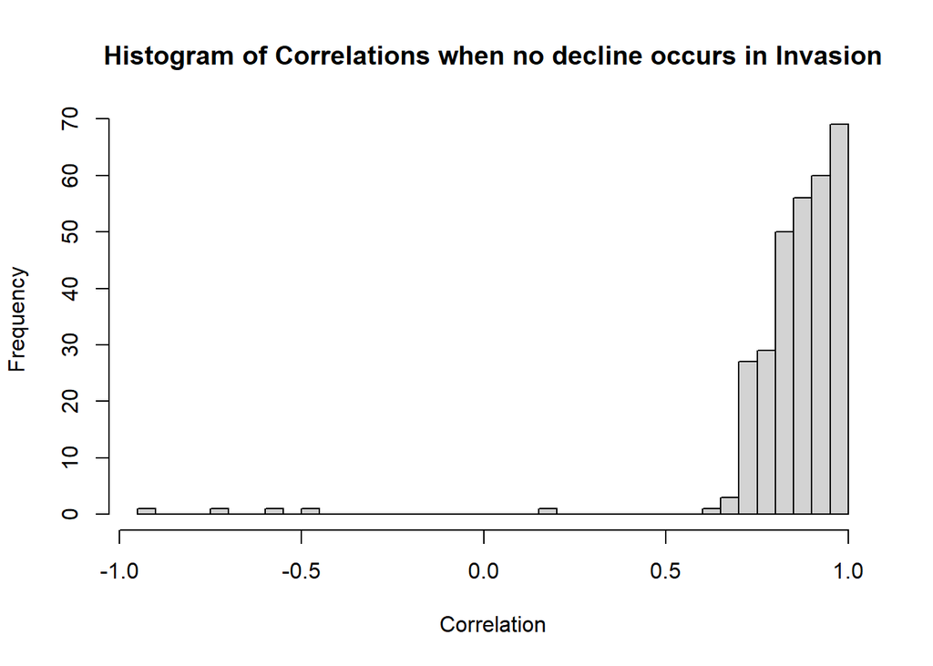

```r
hist(unlist(increase_correlations[2,]), breaks = 50, main = "Histogram of Correlations when no decline occurs in Invasion", xlab = "Correlation")
```

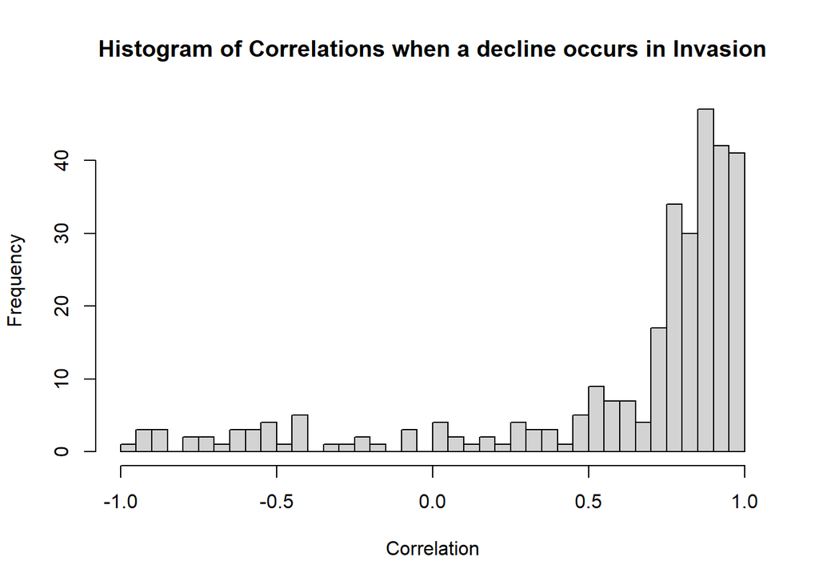

```r
hist(unlist(decrease_correlations[2,]), breaks = 50, main = "Histogram of Correlations when a decline occurs in Invasion", xlab = "Correlation")
```

```r
d_slopes = numeric(length(decrease_correlations[5,]))
dI_slopes = numeric(length(decrease_correlations[5,]))
i_slopes = numeric(length(increase_correlations[5,]))
iI_slopes = numeric(length(increase_correlations[5,]))
start_y = 396
end_y = 417
time = years[start_y:end_y]
for (i in 1:length(d_slopes)){
  y1 = decrease_correlations[5,i]$diff_F[start_y:end_y]
  y2 = increase_correlations[5,i]$diff_F[start_y:end_y]
  yI1 = decrease_correlations[3,i]$results_b1$invasion[start_y:end_y]
  yI2 = increase_correlations[3,i]$results_b1$invasion[start_y:end_y]
  m1 = lm(y1 ~ time)
  m2 = lm(y2 ~ time)
  I1 = lm(yI1 ~ time)
  I2 = lm(yI2 ~ time)
  d_slopes[i] = coef(m1)["time"]
  i_slopes[i] = coef(m2)["time"]
  dI_slopes[i] = coef(I1)["time"]
  iI_slopes[i] = coef(I2)["time"]
}
```

In scenarios where there is no observable decline in actual invasions, the slopes of delta F predominantly exhibit positive values. Conversely, when a decline is evident, these slopes tend to approximate zero, indicating stability rather than growth or reduction over time.

It is crucial to highlight that in scenarios characterized by a lack of decline in actual invasions, the slopes corresponding to the actual invasion rates during the period from 1995 to 2016 predominantly register as zero. This observation implies that the annual rate of new invasions remains constant, resulting in a linear increase in the cumulative number of species invasions. This constancy presents a significant analytical challenge, as it concentrates the distribution of observed I_slopes at zero. This distribution skews our analysis of the relationship between the slopes of delta F and the slopes of actual invasions, potentially obscuring more nuanced trends.

To elucidate more definitive patterns and relationships, it is advisable to adjust the parameters within our simulation models. Specifically, modifications should aim to produce scenarios where the slopes of actual invasions are positive. Such adjustments will allow for a more comprehensive evaluation of the dynamics influencing delta F and thereby enhance the robustness of our conclusions regarding the impact of invasion rates on database discrepancies.

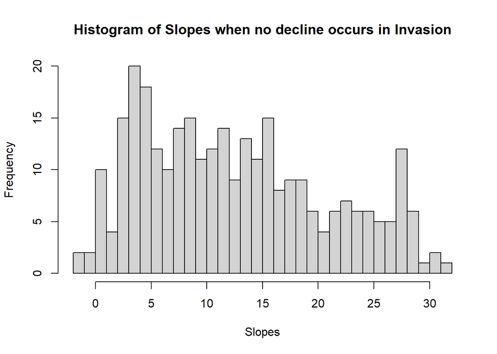

```r
hist(i_slopes, breaks = 30, main = "Histogram of Slopes when no decline occurs in Invasion", xlab = "Slopes")
```

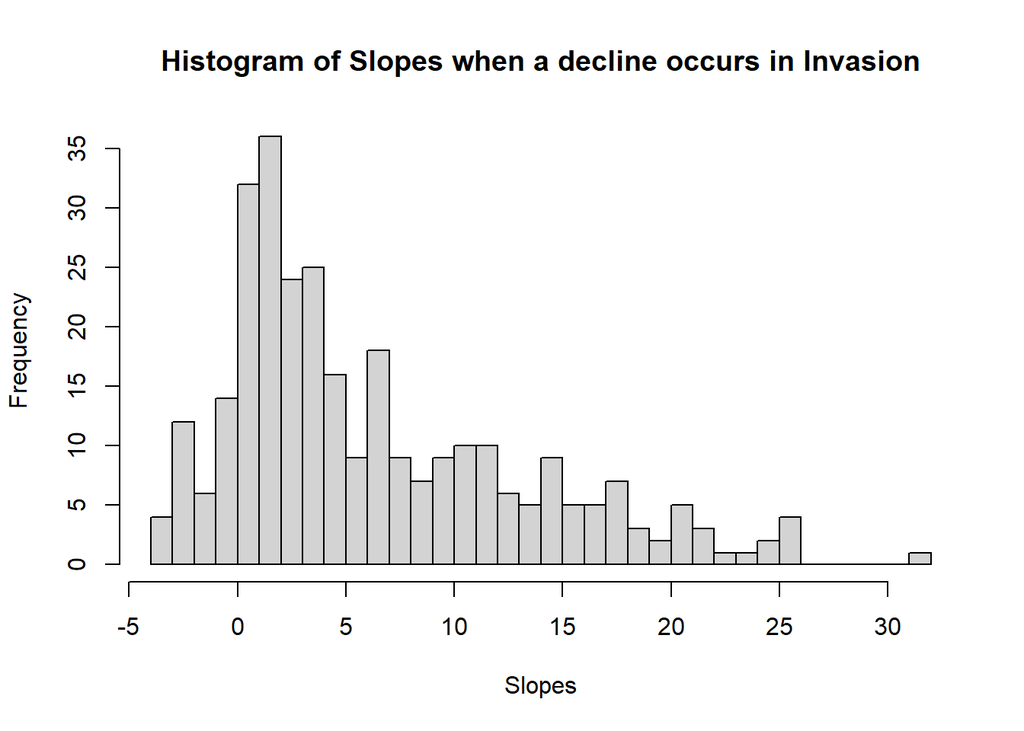

```r
hist(d_slopes, breaks = 30, main = "Histogram of Slopes when a decline occurs in Invasion", xlab = "Slopes")
```

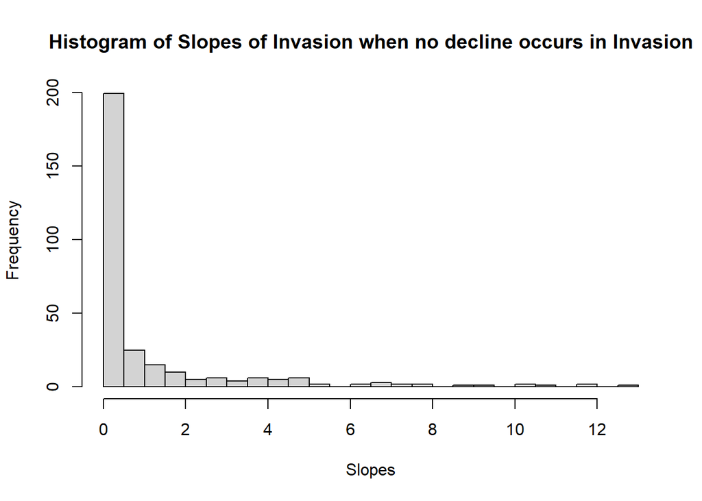

```r
hist(iI_slopes, breaks = 30, main = "Histogram of Slopes of Invasion when no decline occurs in Invasion", xlab = "Slopes")
```

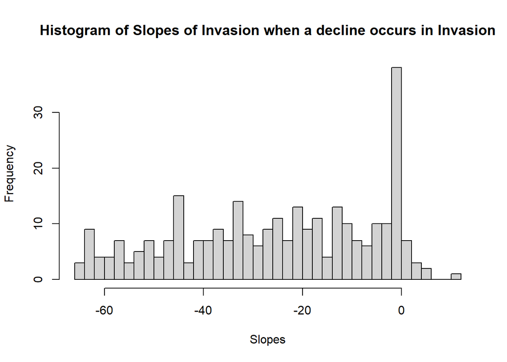

```r
hist(dI_slopes, breaks = 30, main = "Histogram of Slopes of Invasion when a decline occurs in Invasion", xlab = "Slopes")
```

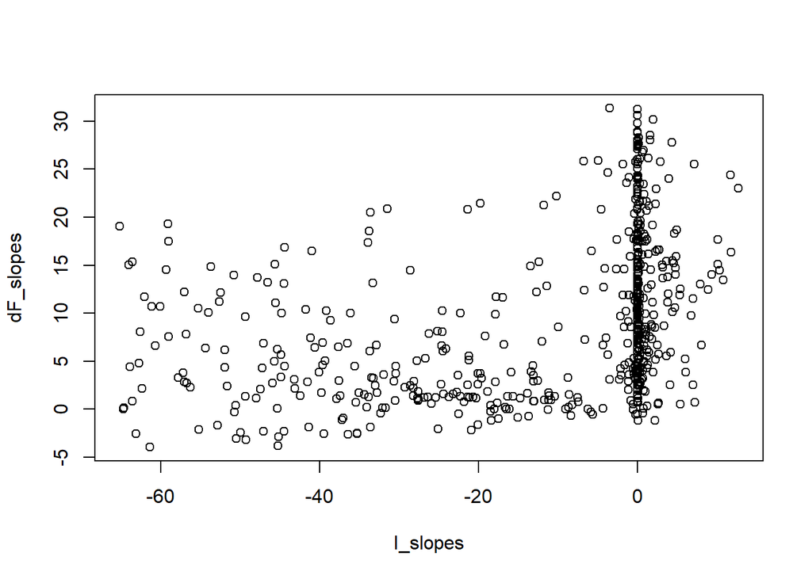

```r
dF_slopes = c(d_slopes, i_slopes)
I_slopes = c(dI_slopes, iI_slopes)
dF_I_lm = lm(dF_slopes ~ I_slopes)
dF_I_slope = coef(dF_I_lm)["I_slopes"]
obs_dF_lm = lm(diff_obs[start_y:end_y]~ time)
obs_df_slope = coef(obs_dF_lm)["time"]
plot(I_slopes, dF_slopes)
```